# Notebook

R es un lenguaje que nació para facilitar la programación estadística. Esta parte es la más fácil de R.

En las primeras páginas de cualquier libro de estadística no encontraremos con lo siguiente a trabajar con cualquier serie de datos.

-- Compete introducir los datos a R:

```r
datos <- c(23, 24, 53, 43, 23, 43, 65, 34, 23, 43, 25, 46, 34, 32)
```

```r
datos
```

1. 23

2. 24

3. 53

4. 43

5. 23

6. 43

7. 65

8. 34

9. 23

10. 43

11. 25

12. 46

13. 34

14. 32

La tabla más básica que puede facilitarnos R es la siguiente:

```r
summary(datos)
```

```
   Min. 1st Qu.  Median    Mean 3rd Qu.    Max.
  23.00   24.25   34.00   36.50   43.00   65.00
```

*Contiene el mínimo, el primer cuartil, la mediana, la media, el tercer cuartil y el valor máximo. Antes de cualquier trabajo con los datos es necesario conocer estos valores.*

R también nos permite obtenerlos de manera individual. --Obtener el valor mínimo.

```r
min(datos)
```

23

--Obtener el valor máximo.

```r
max(datos)
```

65

--Obtener el promedio o media de los valores.

```r
mean(datos)
```

36.5

--Obtener la mediana que es el valor que está en el centro de los datos después de ordenar estos de menor a mayor o viceversa.

```r
median(datos)
```

34

--Obtener el rango que son los dos valores extremos, en algunos libros es presentar el mínimo y el máximo, en otros es la resta de los mismos.

```r
range(datos)
```

1. 23

2. 65

--El único nos presenta los valores una sola vez sin importar cuánto se repitan.

```r
unique(datos)
```

1. 23

2. 24

3. 53

4. 43

5. 65

6. 34

7. 25

8. 46

9. 32

--Lamentablemente R no nos da una función predeterminada para obtener la moda. La moda es la/s observación/nes que más veces se repite/n en la serie de datos. Tenemos que crear una función para nuestro si lo queremos automatizar. Ejemplo: Crear una función llamada statmod.

```r
statmod <- function(x) {
    z <- table(as.vector(x))
    names(z)[z == max(z)]
}
```

Si no somos fanáticos a programar, entonces con una simple observación podemos identificar la moda. Es útil aplicar table cuando los datos son pocos. La primera fila son las observaciones y la segunda las veces que aparecen en los datos. En el ejemplo, el 23 y el 43 son las modas.

```r
table(datos)
```

```
datos
23 24 25 32 34 43 46 53 65
 3  1  1  1  2  3  1  1  1
```

--Si aplicamos nuestra nueva función llegaremos al resultado.

```r
statmod(datos)
```

1. '23'

2. '43'

--Otra información útil conocer cuántas observaciones posee la serie de datos.

```r
length(datos)
```

14

--La desviación estándar. La medida de dispersión de los datos alrededor de su media o mediana.

```r
sd(datos)
```

12.9183828471142

--El cuadrado de la desviación estándar.

```r
var(datos)
```

166.884615384615

```r
12.9183828471142*12.9183828471142
```

166.884615384614

Tener una idea de cómo se distribuye la serie de datos es de vital importacia. Una acción es obtener las tablas de frecuencias y graficarla. Vea la secuencia que realizo para obtenerlas.

# Tablas de Frecuencias

Si el analista cuenta con los datos necesarios para realizar su trabajo, lo primero a hacer será entender los datos con los que se cuenta. Se supone que los datos se refieren a las ventas en unidades de los últimos 10 años los que se muestran a continuación:

*Ventas*

```r
ventas <- c(2540, 2560, 2612, 2630, 2720,
           2760, 2785, 2804, 2831, 2935)
```

```r
table(ventas)
```

```
ventas
2540 2560 2612 2630 2720 2760 2785 2804 2831 2935
   1    1    1    1    1    1    1    1    1    1
```

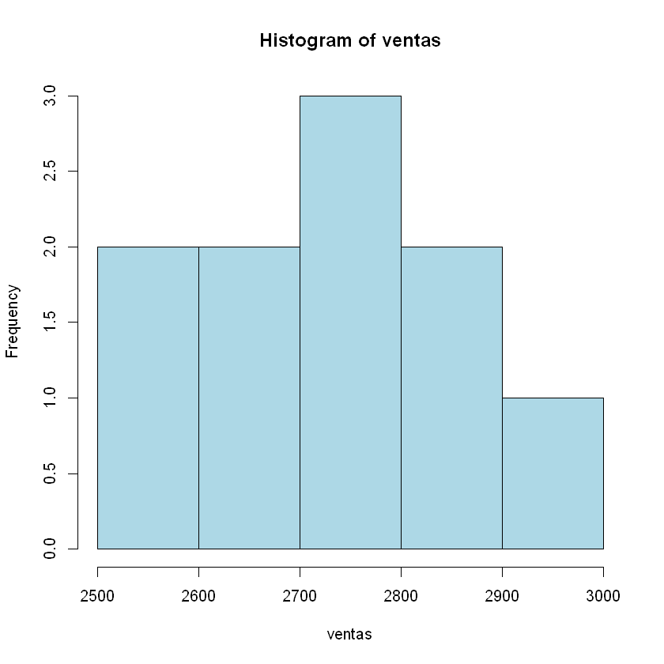

```r
his <- hist(ventas, breaks = 5, col = "lightblue", border = "black")
his
```

```r
hiss <- unclass(his)
hiss
```

**$breaks**

1. 2500

2. 2600

3. 2700

4. 2800

5. 2900

6. 3000

**$counts**

1. 2

2. 2

3. 3

4. 2

5. 1

**$density**

1. 0.002

2. 0.002

3. 0.003

4. 0.002

5. 0.001

**$mids**

1. 2550

2. 2650

3. 2750

4. 2850

5. 2950

**$xname**

'ventas'

**$equidist**

TRUE

```r
Clases <- c('<=2600',
           '(2600, 2700]',
           '(2700, 2800]',
           '(2800, 2900]',
           '(2900, 3000]')
```

```r
Frecuencia <- as.numeric(hiss$counts)
Frecuencia
```

1. 2

2. 2

3. 3

4. 2

5. 1

```r
Frecuencia_relativa <- (hiss$density)*100
Frecuencia_relativa
```

1. 0.2

2. 0.2

3. 0.3

4. 0.2

5. 0.1

```r
Frecuencia_acumulada <- cumsum(Frecuencia)
Frecuencia_acumulada
```

1. 2

2. 4

3. 7

4. 9

5. 10

```r
Frecuencia_relativa_acumulada <- cumsum(Frecuencia_relativa)
Frecuencia_relativa_acumulada
```

1. 0.2

2. 0.4

3. 0.7

4. 0.9

5. 1

```r
Tabla <- data.frame(Clases, Frecuencia, Frecuencia_relativa, Frecuencia_acumulada, Frecuencia_relativa_acumulada)
Tabla
```

| Clases | Frecuencia | Frecuencia_relativa | Frecuencia_acumulada | Frecuencia_relativa_acumulada |
| --- | --- | --- | --- | --- |
| <=2600 | 2 | 0.2 | 2 | 0.2 |
| (2600, 2700] | 2 | 0.2 | 4 | 0.4 |
| (2700, 2800] | 3 | 0.3 | 7 | 0.7 |
| (2800, 2900] | 2 | 0.2 | 9 | 0.9 |
| (2900, 3000] | 1 | 0.1 | 10 | 1.0 |

```r
colSums(Tabla[,2:3])
```

**Frecuencia**

10

**Frecuencia_relativa**

1